# Analysis for Views of Science and the Future

## PIAL4-b vs. 1-a

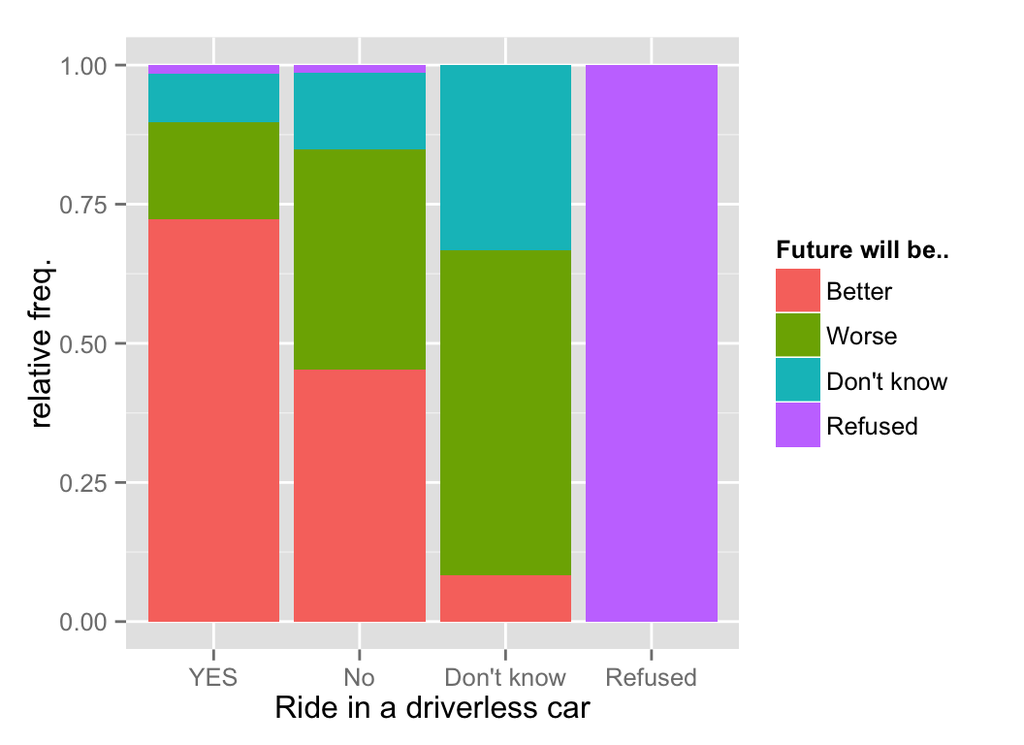

## PIAL4-c vs. 1-a

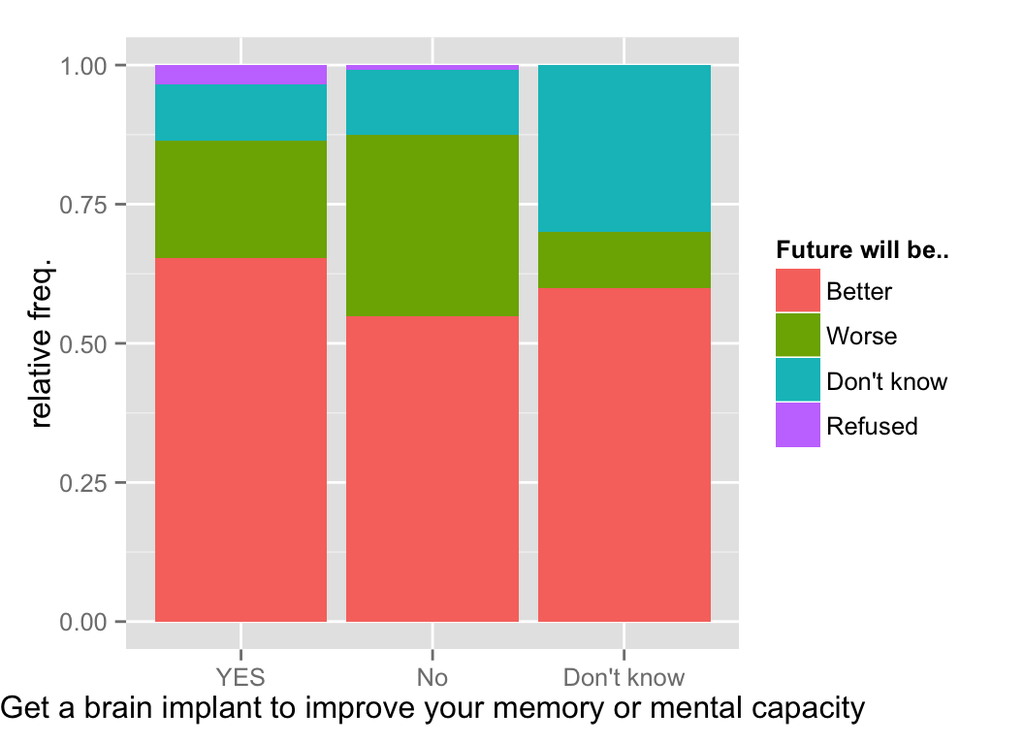

## PIAL3-a vs. 1-a

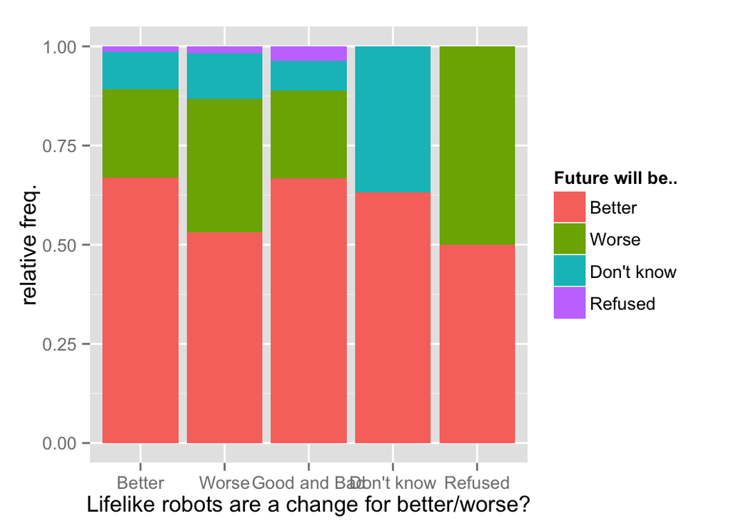

## PIAL3-b vs. 1-a

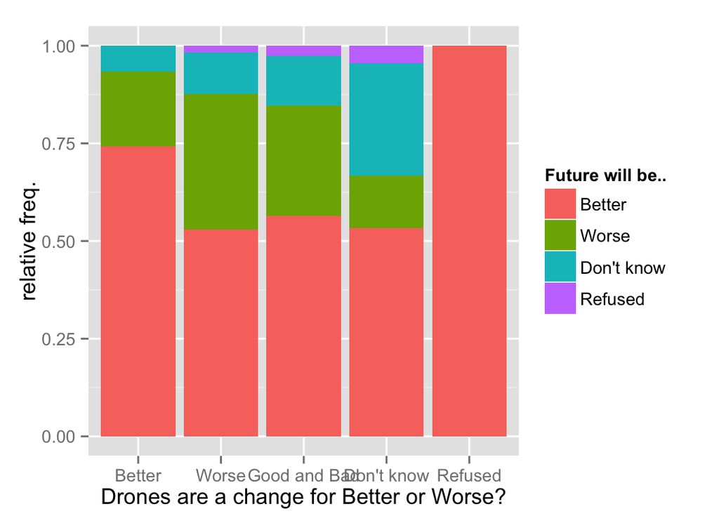

## PIAL3-c vs. 1-a

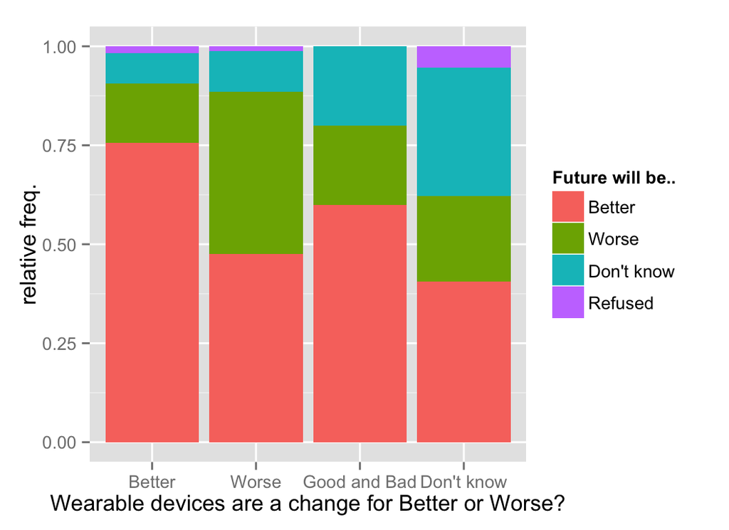

## PIAL3-d vs. 1-a

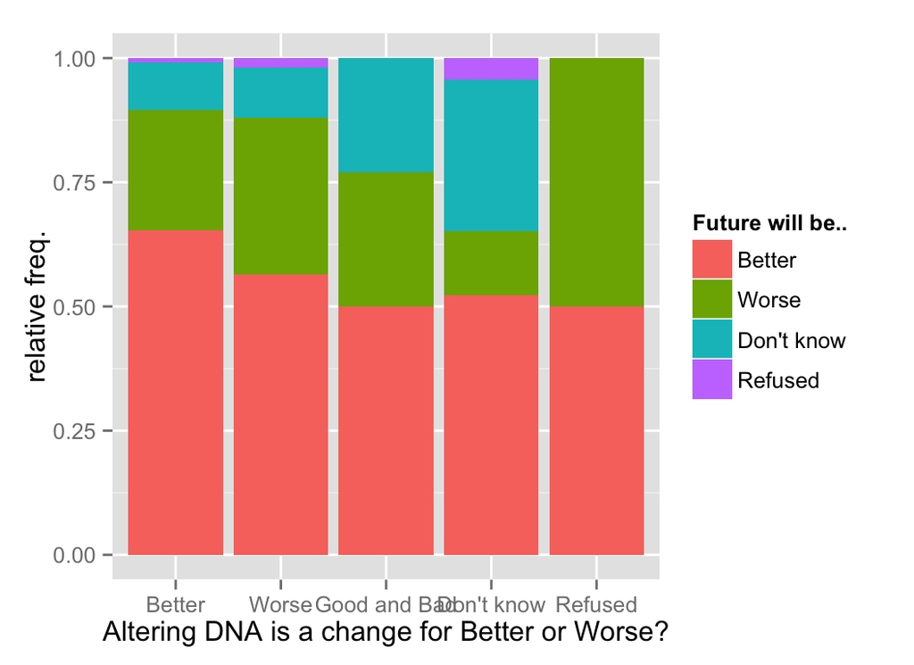

## Design Plan (Initial)

1. Histogram showing the relative frequency of views on the future.
2. Future vs. Income stacked bar plot. People with higher income are more positive about the future.
3. Animating histogram showing the relative frequency of views on each technology. You can interactively select a technology and see how the views change.

## Design Plan (Update)

1. Histogram showing the relative frequency of views on the future.
2. Histogram showing the relative frequency of income combined with future vs. income stacked bar plot. People with higher income are more positive about the future.
3. Histograms showing the relative frequency of attitudes toward each technology (PIAL4a-c) combined with a line graph showing the relative frequency of views on the future.